# Predict the criminal - using Python and Meta-Stacked-Classifier

There has been a surge in crimes committed in recent years, making crime a top cause of concern for law enforcement. If we are able to estimate whether someone is going to commit a crime in the future, we can take precautions and be prepared. The prediction accounts for the psychological aspects of human activities and study of those factors which affects the human crimes the most. We have a dataset containing answers to various questions concerning the professional and private lives of several people. **A few of them have been arrested for various small and large crimes in the past.** We have used the given data to predict if the people in the test data will commit a crime.

## Data description

**Variable Name Description**

- PERID --> Person ID
- IFATHER --> FATHER IN HOUSEHOLD
- NRCH17_2 --> RECODED # R's CHILDREN < 18 IN HOUSEHOLD
- IRHHSIZ2 --> RECODE - IMPUTATION-REVISED # PERSONS IN HH
- IIHHSIZ2 --> IMPUTATION INDICATOR
- IRKI17_2 --> IMPUTATION-REVISED # KIDS AGED LESS THAN 18 IN HH
- IIKI17_2 --> IRKI17_2-IMPUTATION INDICATOR
- IRHH65_2 --> REC - IMPUTATION-REVISED # OF PER IN HH AGED GRATER OR EQUAL 65
- IIHH65_2 --> IRHH65_2-IMPUTATION INDICATOR
- PRXRETRY --> SELECTED PROXY UNAVAILABLE, OTHER PROXY AVAILABLE?
- PRXYDATA --> IS PROXY ANSWERING INSURANCE/INCOME QS
- MEDICARE --> COVERED BY MEDICARE
- CAIDCHIP --> COVERED BY MEDICAID/CHIP
- CHAMPUS --> COV BY TRICARE, CHAMPUS, CHAMPVA, VA, MILITARY
- PRVHLTIN --> COVERED BY PRIVATE INSURANCE
- GRPHLTIN --> PRIVATE PLAN OFFERED THROUGH EMPLOYER OR UNION
- HLTINNOS --> COVERED BY HEALTH INSUR
- HLCNOTYR --> ANYTIME DID NOT HAVE HEALTH INS/COVER PAST 12 MOS
- HLCNOTMO --> PAST 12 MOS, HOW MANY MOS W/O COVERAGE
- HLCLAST --> TIME SINCE LAST HAD HEALTH CARE COVERAGE
- HLLOSRSN --> MAIN REASON STOPPED COVERED BY HEALTH INSURANCE
- HLNVCOST --> COST TOO HIGH
- HLNVOFFR --> EMPLOYER DOESN'T OFFER
- HLNVREF --> INSURANCE COMPANY REFUSED COVERAGE
- HLNVNEED --> DON'T NEED IT
- HLNVSOR --> NEVER HAD HLTH INS SOME OTHER REASON
- IRMCDCHP --> IMPUTATION REVISED CAIDCHIP
- IIMCDCHP --> MEDICAID/CHIP - IMPUTATION INDICATOR
- IRMEDICR --> MEDICARE - IMPUTATION REVISED
- IIMEDICR --> MEDICARE - IMPUTATION INDICATOR
- IRCHMPUS --> CHAMPUS - IMPUTATION REVISED
- IICHMPUS --> CHAMPUS - IMPUTATION INDICATOR
- IRPRVHLT --> PRIVATE HEALTH INSURANCE - IMPUTATION REVISED
- IIPRVHLT --> PRIVATE HEALTH INSURANCE - IMPUTATION INDICATOR
- IROTHHLT --> OTHER HEALTH INSURANCE - IMPUTATION REVISED
- IIOTHHLT --> OTHER HEALTH INSURANCE - IMPUTATION INDICATOR
- HLCALLFG --> FLAG IF EVERY FORM OF HEALTH INS REPORTED
- HLCALL99 --> YES TO MEDICARE/MEDICAID/CHAMPUS/PRVHLTIN
- ANYHLTI2 --> COVERED BY ANY HEALTH INSURANCE - RECODE
- IRINSUR4 --> RC-OVERALL HEALTH INSURANCE - IMPUTATION REVISED
- IIINSUR4 --> RC-OVERALL HEALTH INSURANCE - IMPUTATION INDICATOR
- OTHINS --> RC-OTHER HEALTH INSURANCE
- CELLNOTCL --> NOT A CELL PHONE
- CELLWRKNG --> WORKING CELL PHONE
- IRFAMSOC --> FAM RECEIVE SS OR RR PAYMENTS - IMPUTATION REVISED
- IIFAMSOC --> FAM RECEIVE SS OR RR PAYMENTS - IMPUTATION INDICATOR
- IRFAMSSI --> FAM RECEIVE SSI - IMPUTATION REVISED
- IIFAMSSI --> FAM RECEIVE SSI - IMPUTATION INDICATOR
- IRFSTAMP --> RESP/OTH FAM MEM REC FOOD STAMPS - IMPUTATION REVISED
- IIFSTAMP --> RESP/OTH FAM MEM REC FOOD STAMPS - IMPUTATION INDICATOR
- IRFAMPMT --> FAM RECEIVE PUBLIC ASSIST - IMPUTATION REVISED
- IIFAMPMT --> FAM RECEIVE PUBLIC ASSIST - IMPUTATION INDICATOR
- IRFAMSVC --> FAM REC WELFARE/JOB PL/CHILDCARE - IMPUTATION REVISED
- IIFAMSVC --> FAM REC WELFARE/JOB PL/CHILDCARE - IMPUTATION INDICATOR
- IRWELMOS --> IMP. REVISED - NO.OF MONTHS ON WELFARE
- IIWELMOS --> NO OF MONTHS ON WELFARE - IMPUTATION INDICATOR
- IRPINC3 --> RESP TOT INCOME (FINER CAT) - IMP REV
- IRFAMIN3 --> RECODE - IMP.REVISED - TOT FAM INCOME
- IIPINC3 --> RESP TOT INCOME (FINER CAT) - IMP INDIC
- IIFAMIN3 --> IRFAMIN3 - IMPUTATION INDICATOR
- GOVTPROG --> RC-PARTICIPATED IN ONE OR MORE GOVT ASSIST PROGRAMS
- POVERTY3 --> RC-POVERTY LEVEL
- TOOLONG --> RESP SAID INTERVIEW WAS TOO LONG
- TROUBUND --> DID RESP HAVE TROUBLE UNDERSTANDING INTERVIEW
- PDEN10 --> POPULATION DENSITY 2010
- COUTYP2 --> COUNTY METRO/NONMETRO STATUS
- MAIIN102 --> MAJORITY AMER INDIAN AREA INDICATOR FOR SEGMENT
- AIIND102 --> AMER INDIAN AREA INDICATOR
- ANALWT_C --> FIN PRSN-LEVEL SIMPLE WGHT
- VESTR --> ANALYSIS STRATUM
- VEREP --> ANALYSIS REPLICATE
- Criminal --> Target Variable

## Code and Visualization

```python
# importing Libraries
import numpy as np
import pandas as pd
import xgboost as xgb
import seaborn as sns
import lightgbm as lgb
from sklearn.svm import SVC
import matplotlib.pylab as plt
import matplotlib.pyplot as plote
from sklearn import preprocessing
from xgboost.sklearn import XGBClassifier
from sklearn import cross_validation, metrics
from sklearn.model_selection import train_test_split
from pylab import plot, show, subplot, specgram, imshow, savefig
```

```python
# Reading dataset
dataset = pd.read_csv('../input/criminal_train.csv')
```

```python
# The first 5 rows of dataset
dataset.head(5)
```

|  | PERID | IFATHER | NRCH17_2 | IRHHSIZ2 | IIHHSIZ2 | IRKI17_2 | IIKI17_2 | IRHH65_2 | IIHH65_2 | PRXRETRY | ... | TOOLONG | TROUBUND | PDEN10 | COUTYP2 | MAIIN102 | AIIND102 | ANALWT_C | VESTR | VEREP | Criminal |
| --- | --- | --- | --- | --- | --- | --- | --- | --- | --- | --- | --- | --- | --- | --- | --- | --- | --- | --- | --- | --- | --- |
| 0 | 25095143 | 4 | 2 | 4 | 1 | 3 | 1 | 1 | 1 | 99 | ... | 1 | 2 | 1 | 1 | 2 | 2 | 3884.805998 | 40026 | 1 | 0 |
| 1 | 13005143 | 4 | 1 | 3 | 1 | 2 | 1 | 1 | 1 | 99 | ... | 2 | 2 | 2 | 3 | 2 | 2 | 1627.108106 | 40015 | 2 | 1 |
| 2 | 67415143 | 4 | 1 | 2 | 1 | 2 | 1 | 1 | 1 | 99 | ... | 2 | 2 | 2 | 3 | 2 | 2 | 4344.957980 | 40024 | 1 | 0 |
| 3 | 70925143 | 4 | 0 | 2 | 1 | 1 | 1 | 1 | 1 | 99 | ... | 2 | 2 | 1 | 1 | 2 | 2 | 792.521931 | 40027 | 1 | 0 |
| 4 | 75235143 | 1 | 0 | 6 | 1 | 4 | 1 | 1 | 1 | 99 | ... | 2 | 2 | 2 | 2 | 2 | 2 | 1518.118526 | 40001 | 2 | 0 |

5 rows × 72 columns

```python
# feature scaling
dataset.VESTR = preprocessing.scale(dataset.VESTR)
dataset.ANALWT_C = preprocessing.scale(dataset.ANALWT_C)

# separating dependent and independent variable
# dropping IDs
target = dataset.Criminal
features = dataset.drop(['Criminal','PERID'], axis = 1)
```

#### CountPlot of dependent variable

```
Text(0.5,1,'Criminal Count')
```

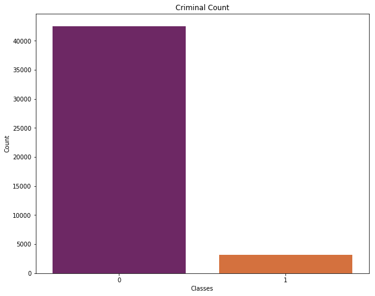

```python
ax=plote.figure(figsize=(10,8))
ax=sns.countplot(x="Criminal",palette="inferno",data=dataset)
ax.set_xlabel("Classes")
ax.set_ylabel("Count")
ax.set_title("Criminal Count")
```

The plot of the dependent variable shows that the dataset is highly imbalanced.

### Plotting Feature importance For XGBoost Classifier

Ranking the features according to their importance in classification in XGB.

```python
xgb = XGBClassifier(
 learning_rate =0.01,
 n_estimators=1000,
 max_depth=5,
 min_child_weight=5,
 gamma=0.3,
 subsample=0.7,
 colsample_bytree=0.6,
 reg_aplha=1.68,
 objective= 'binary:logistic',
 nthread=4,
 scale_pos_weight=1,
 seed=27)

xgb = xgb.fit(features, target)
```

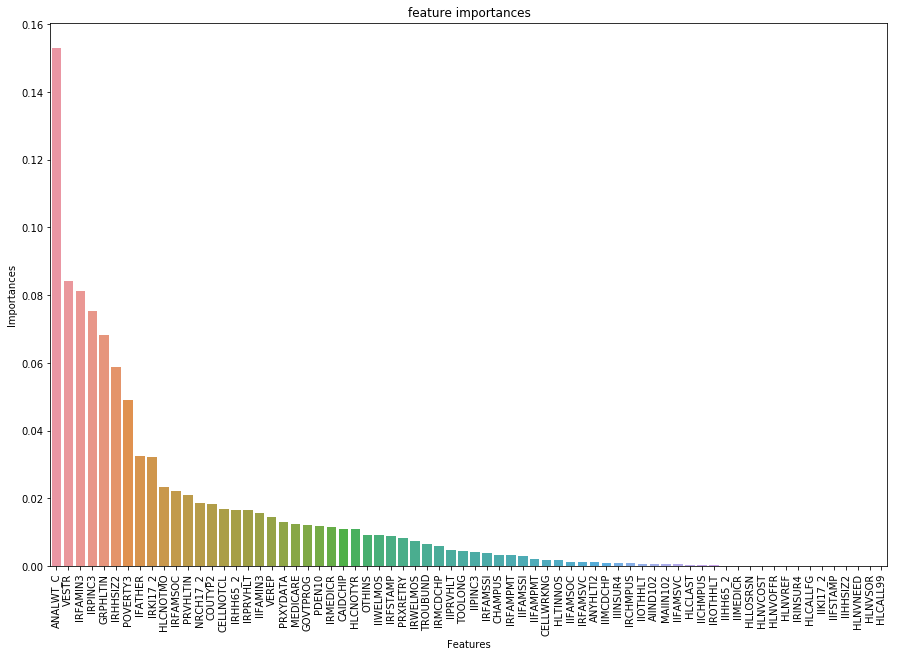

```python
importances = xgb.feature_importances_
feature_names = features.columns.values
data = pd.DataFrame({'features': feature_names,'importances':importances})
new_index = (data['importances'].sort_values(ascending=False)).index.values
sorted_data = data.reindex(new_index)
plt.figure(figsize=(15,10))
ax= sns.barplot(x=sorted_data['features'], y=sorted_data['importances'])
plt.xticks(rotation= 90)
plt.xlabel('Features')
plt.ylabel('Importances')
plt.title('feature importances')
plt.show()
```

The importance of various features are shown. We selecting the top features according to the above importance graph.

```python
optimal_features_xgb = ['IFATHER', 'NRCH17_2', 'IRHHSIZ2', 'IRKI17_2', 'IRHH65_2', 'PRXYDATA', 'MEDICARE', 'CAIDCHIP', \
            'GRPHLTIN', 'HLCNOTMO', 'IRMCDCHP', 'OTHINS', 'CELLNOTCL', 'IRFAMSOC', 'IRFSTAMP', 'IRWELMOS',\
            'IRPINC3', 'IRFAMIN3', 'IIFAMIN3', 'GOVTPROG', 'POVERTY3', 'TOOLONG', 'TROUBUND', 'PDEN10',\
            'COUTYP2', 'ANALWT_C', 'VESTR', 'VEREP', 'PRVHLTIN', 'IRPRVHLT', 'IRMEDICR', 'IIWELMOS']
```

### Plotting Feature importances for Linear SVM

```python
svm = SVC(kernel='linear', C=4)
svm.fit(features, target)
```

```
SVC(C=4, cache_size=200, class_weight=None, coef0=0.0,
  decision_function_shape='ovr', degree=3, gamma='auto', kernel='linear',
  max_iter=-1, probability=False, random_state=None, shrinking=True,
  tol=0.001, verbose=False)
```

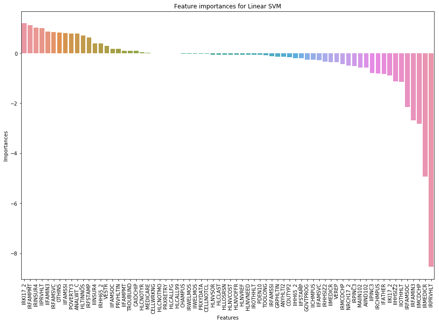

```python
importances = svm.coef_
features_names = features.columns.values
data = pd.DataFrame({'features': feature_names,'importances':importances[0]})
new_index = (data['importances'].sort_values(ascending=False)).index.values
sorted_data = data.reindex(new_index)
plt.figure(figsize=(15,10))
ax= sns.barplot(x=sorted_data['features'], y=sorted_data['importances'])
plt.xticks(rotation= 90)
plt.xlabel('Features')
plt.ylabel('Importances')
plt.title('Feature importances for Linear SVM')
plt.show()
```

The positive and negative values in the graph shows the role of feature in classifying positive and negative values. Therefore we select the extremities of the features for both the classes.

```python
optimal_features_LSVM = ['IRKI17_2', 'IRFAMPMT', 'IRINSUR4', 'IIPRVHLT', 'IIFAMIN3',
       'IRFAMSVC', 'OTHINS', 'IIFAMSSI','IFATHER', 'IIKI17_2', 'IIHHSIZ2','IIOTHHLT',\
        'IRFAMSOC', 'IRFAMIN3', 'IIMCDCHP', 'IRMEDICR','IRPRVHLT']
```

### Plotting Feature importance in LightGBM

```python
train_data=lgb.Dataset(features,label=target)
param = {'num_leaves':120,'max_depth':5,'learning_rate':.1,'max_bin':1200}
num_round=50
lgbm=lgb.train(param,train_data,num_round)
```

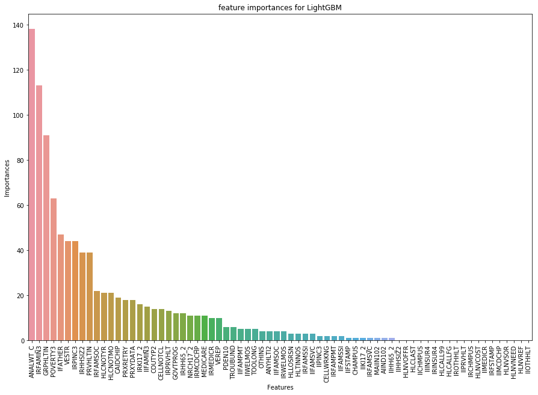

```python
importances = lgbm.feature_importance(importance_type='split')
features_names = features.columns.values
data = pd.DataFrame({'features': feature_names,'importances':importances})
new_index = (data['importances'].sort_values(ascending=False)).index.values
sorted_data = data.reindex(new_index)
plt.figure(figsize=(15,10))
ax= sns.barplot(x=sorted_data['features'], y=sorted_data['importances'])
plt.xticks(rotation= 90)
plt.xlabel('Features')
plt.ylabel('Importances')
plt.title('feature importances for LightGBM')
plt.show()
```

We select features according to its importances as shown in the graph.

```python
optimal_features_LGBM = sorted_data[0:27].features.values
```

### XGBoost Classifier

The features are filtered according to the importance derived from the feature importance graph of XGB

```python
X_train, X_test, y_train, y_test = train_test_split(features[optimal_features_xgb], target ,test_size=0.4, random_state=7)
X_cv, X_test, y_cv, y_test = train_test_split(X_test, y_test ,test_size=0.5, random_state=7)
```

```python
xgb = XGBClassifier(
 learning_rate =0.01,
 n_estimators=1000,
 max_depth=5,
 min_child_weight=5,
 gamma=0.3,
 subsample=0.7,
 colsample_bytree=0.6,
 reg_alpha=0.5,
 objective= 'binary:logistic',
 nthread=4,
 scale_pos_weight=1,
 seed=27)
```

```python
xgb = xgb.fit(X_train, y_train)
res_xgb = xgb.predict(X_test)
score_xgb = metrics.accuracy_score(res_xgb, y_test)
print("Accuracy : %.4g" % score_xgb)
```

```
Accuracy : 0.9561
```

```python
# getting probability for test and cross validation
element_xgb = xgb.predict_proba(X_test)
elementcv_xgb = xgb.predict_proba(X_cv)
```

### kernel SVM

We follow the same features selected in XGBoost because SVM doesn't have a feature importance metric and including all features are inefficient due to the large amount of features.

```python
clf = SVC(kernel='rbf',C=4,probability=True)
clf.fit(X_train, y_train)
res_ksvm = clf.predict(X_test)
score_ksvm = metrics.accuracy_score(res_ksvm, y_test)
print("Accuracy : %.4g" % score_ksvm)
```

```
Accuracy : 0.9536
```

```python
element_ksvm = clf.predict_proba(X_test)
elementcv_ksvm = clf.predict_proba(X_cv)
```

### LGBoost

The features are filtered according to the feature importance graph of LGBoost

```python
X_train, X_test, y_train, y_test = train_test_split(features[optimal_features_LGBM], target ,test_size=0.4, random_state=7)
X_cv, X_test, y_cv, y_test = train_test_split(X_test, y_test ,test_size=0.5, random_state=7)
```

```python
train_data=lgb.Dataset(X_train,label=y_train)
param = {'num_leaves':120,'max_depth':5,'learning_rate':.1,'max_bin':1200}
num_round=50
lgbm=lgb.train(param,train_data,num_round)
```

```python
ypred2=lgbm.predict(X_test)
res3 = (ypred2 >= .5).astype(int)
score_lgbm = metrics.accuracy_score(res3, y_test)
print("Accuracy : %.4g" % score_lgbm)
```

```
Accuracy : 0.9561
```

```python
# for test set
temp = pd.DataFrame(np.zeros((len(ypred2), 1)))

for i in range(0,len(ypred2)):
    temp[0][i] = ypred2[i]

temp2 = 1-temp
para3 = pd.concat([temp2,temp], axis = 1)
element_lgb = para3.values

# for cv set
pred_cv = lgbm.predict(X_cv)
temp = pd.DataFrame(np.zeros((len(pred_cv), 1)))

for i in range(0,len(pred_cv)):
    temp[0][i] = pred_cv[i]

temp2 = 1-temp
para3 = pd.concat([temp2,temp], axis = 1)
elementcv_lgb = para3.values
```

## Linear SVM

```python
X_train, X_test, y_train, y_test = train_test_split(features[optimal_features_LSVM], target ,test_size=0.4, random_state=7)
X_cv, X_test, y_cv, y_test = train_test_split(X_test, y_test ,test_size=0.5, random_state=7)
```

```python
svm = SVC(kernel='linear', C=3)
svm.fit(X_train, y_train)
```

```
SVC(C=3, cache_size=200, class_weight=None, coef0=0.0,
  decision_function_shape='ovr', degree=3, gamma='auto', kernel='linear',
  max_iter=-1, probability=False, random_state=None, shrinking=True,
  tol=0.001, verbose=False)
```

```python
res_svm = svm.predict(X_test)
score_lsvm = metrics.accuracy_score(res_svm, y_test)
print("Accuracy : %.4g" % score_lsvm)
```

```
Accuracy : 0.9373
```

### Neural Networks Keras

```python
import keras
from keras.models import Sequential
from keras.layers import Dense

X_train, X_test, y_train, y_test = train_test_split(features, target ,test_size=0.4, random_state=7)
X_cv, X_test, y_cv, y_test = train_test_split(X_test, y_test ,test_size=0.5, random_state=7)
# Initialising the ANN
classifier = Sequential()

# Adding the input layer and the first hidden layer
classifier.add(Dense(output_dim = 6, init = 'uniform', activation = 'relu', input_dim = 70))

# Adding the second hidden layer
classifier.add(Dense(output_dim = 6, init = 'uniform', activation = 'relu'))

# Adding the output layer
classifier.add(Dense(output_dim = 1, init = 'uniform', activation = 'sigmoid'))

# Compiling the ANN
classifier.compile(optimizer = 'adam', loss = 'binary_crossentropy', metrics = ['accuracy'])

# Fitting the ANN to the Training set
classifier.fit(X_train, y_train, batch_size = 10, nb_epoch = 100)
```

```
<keras.callbacks.History at 0x7fe6d0463080>
```

```python
# for test set
pred_nn = classifier.predict(X_test)
res_nn = (pred_nn >= .5).astype(int)
score_nn = metrics.accuracy_score(res_nn, y_test)
print("Accuracy : %.4g" % score_nn)
```

```
Accuracy : 0.9545
```

```python
# for test set
temp = pd.DataFrame(np.zeros((len(pred_nn), 1)))

for i in range(0,len(pred_nn)):
    temp[0][i] = pred_nn[i]

temp2 = 1-temp
para4 = pd.concat([temp2,temp], axis = 1)
element_nn = para4.values

# for cross validation set
pred_nn = classifier.predict(X_cv)
temp = pd.DataFrame(np.zeros((len(pred_nn), 1)))

for i in range(0,len(pred_nn)):
    temp[0][i] = pred_nn[i]

temp2 = 1-temp
para4 = pd.concat([temp2,temp], axis = 1)
elementcv_nn = para4.values
```

## Stacking

The four most efficient algorithms are stacked to predict the final output. Each algorithm produces probabilties for each class(here 0 and 1). Mean of probabilties is calculated from all four algorithms and used to calculate output. In place of mean we can use two more concepts i.e. finding the most confident output by any algorithm for each test case (max of probabilty) or number of outputs for each class.

```
0.059000000000000004
```

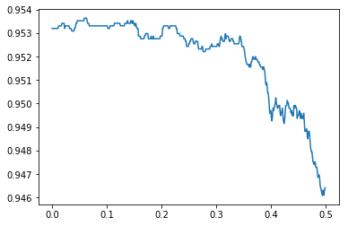

```python
#para3 = para3.values
decide0 = pd.DataFrame(np.zeros((len(elementcv_nn), 4)))
decide1 = pd.DataFrame(np.zeros((len(elementcv_nn), 4)))
decide0 = decide0.values
decide1 = decide1.values
for i in range(0,len(decide0)):
    """decide0[i][0] = (1 if para1[i][0]>0.5 else 0)
    decide0[i][1] = (1 if para2[i][0]>0.5 else 0)
    decide0[i][2] = (1 if para31[i][0]>0.5 else 0)
    decide1[i][0] = (1 if para1[i][1]>0.5 else 0)
    decide1[i][1] = (1 if para2[i][1]>0.5 else 0)
    decide1[i][2] = (1 if para31[i][1]>0.5 else 0)"""
    decide0[i][0] = elementcv_xgb[i][0]
    decide0[i][1] = elementcv_lgb[i][0]
    decide0[i][2] = elementcv_ksvm[i][0]
    decide0[i][3] = elementcv_nn[i][0]
    decide1[i][0] = elementcv_xgb[i][1]
    decide1[i][1] = elementcv_lgb[i][1]
    decide1[i][2] = elementcv_ksvm[i][1]
    decide1[i][3] = elementcv_nn[i][1]
k0 = decide0.mean(axis=1)
k1 = decide1.mean(axis=1)
def get_acc(thresh, k0=k0,k1=k1):
    final = pd.DataFrame(np.zeros((len(k0), 1)))
    for i in range(0,len(k0)):
        if (k0[i]-k1[i])>thresh:
            final[0][i]=0
        else:
            final[0][i]=1
    return metrics.accuracy_score(y_cv, final)
#print(get_acc(0.081))
t = np.arange(0.0, 0.5, 0.001)
s = np.empty([500,1])
i=0
maxi = 0.0
iind = 0
for item in t:
    h = get_acc(item)
    s[i] = h
    if h>maxi:
        maxi = h
        iind = i
    i = i+1
print(iind*0.001)
plote.plot(t,s)
plote.show()
```

```python
#para3 = para3.values

decide0 = pd.DataFrame(np.zeros((len(element_nn), 4)))
decide1 = pd.DataFrame(np.zeros((len(element_nn), 4)))
decide0 = decide0.values
decide1 = decide1.values
for i in range(0,len(decide0)):
    """decide0[i][0] = (1 if para1[i][0]>0.5 else 0)
    decide0[i][1] = (1 if para2[i][0]>0.5 else 0)
    decide0[i][2] = (1 if para31[i][0]>0.5 else 0)
    decide1[i][0] = (1 if para1[i][1]>0.5 else 0)
    decide1[i][1] = (1 if para2[i][1]>0.5 else 0)
    decide1[i][2] = (1 if para31[i][1]>0.5 else 0)"""
    decide0[i][0] = element_xgb[i][0]
    decide0[i][1] = element_lgb[i][0]
    decide0[i][2] = element_ksvm[i][0]
    decide0[i][3] = element_nn[i][0]
    decide1[i][0] = element_xgb[i][1]
    decide1[i][1] = element_lgb[i][1]
    decide1[i][2] = element_ksvm[i][1]
    decide1[i][3] = element_nn[i][1]
k0 = decide0.mean(axis=1)
k1 = decide1.mean(axis=1)

"""final = pd.DataFrame(np.zeros((len(k0), 1)))
for i in range(0,9144):
    if (k0[i]-k1[i])>0.05:
       final[0][i]=0
    else:
       final[0][i]=1

print("Accuracy : %.4g" % metrics.accuracy_score(y_test, final))"""
def get_acc(thresh, k0=k0,k1=k1):
    final = pd.DataFrame(np.zeros((len(k0), 1)))
    for i in range(0,len(k0)):
        if (k0[i]-k1[i])>thresh:
            final[0][i]=0
        else:
            final[0][i]=1
    return metrics.accuracy_score(y_test, final)
print(get_acc(0.095))
t = np.arange(0.0, 0.5, 0.001)
s = np.empty([500,1])
i=0
maxi = 0.0
iind = 0
for item in t:
    h = get_acc(item)
    s[i] = h
    if h>maxi:
        maxi = h
        iind = i
    i = i+1
print(maxi)
print(iind)
```

```
0.956802274716
0.957349081365
137
```

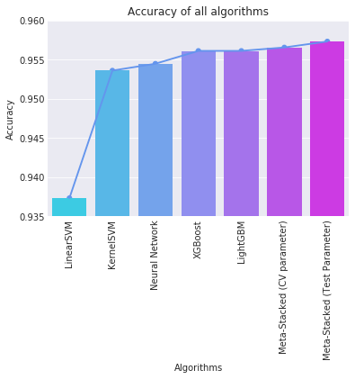

```python
score_testcv = get_acc(0.059)
plt.figure()
x = np.array([score_lsvm,score_ksvm, score_nn,score_xgb,  score_lgbm, score_testcv, maxi])
y = np.array(['LinearSVM','KernelSVM','Neural Network','XGBoost', 'LightGBM', 'Meta-Stacked (CV parameter)', 'Meta-Stacked (Test Parameter)'])
dfx = pd.DataFrame(x)
colors = sns.color_palette("cool", len(x))
ax= sns.barplot(y, x, data=dfx,palette=colors)
ax = sns.pointplot(y, x, color='cornflowerblue', scale=0.7)
ax.set(ylim=(0.935, 0.96))
plt.title("Accuracy of all algorithms")
plt.xticks(rotation= 90)
plt.ylabel('Accuracy')
plt.xlabel('Algorithms')
#adding the text labels
rects = ax.patches
labels = y

plt.show()
```